# Lab 7 Assignment: Group 16

| **Name of the student** | **Student ID** |
| --- | --- |
| Konstantina Gkopi | s243692 |
| Eric Torres | s243275 |
| Lucía de Lamadrid | s243311 |
| Jorge Santiago | s243310 |
| Elena Iriondo | s243312 |

### Introduction

In this assignment, we will perform **Principal Component Analysis (PCA)** on the $iris$ dataset. This dataset comprises 150 samples from three different species of iris flowers (setosa, versicolor and virginica), being each of them characterised by four attributes: sepal length, sepal width, petal length and petal width.

PCA is a powerful dimensionality reduction technique that will help us visualize high-dimensional data (in our case 4D) by transforming it into a lower-dimensional space while preserving as much variance as possible. Through this we aim to uncover the underlying structure of the data and improve our understanding of the relationships between the different $iris$ species.

Additionally, on this assignment our group will use git to work collaboratively on carrying out the PCA on the $iris$ dataset. This is a tidy dataset, so we will not have to prepare the data before analysing it. The dataset consists of a tibble with dimensions $N$ = 150 and $M$ = 5, where $N$ is the number of observations and $M$ the number of features. The label is `species`:

```r
head(iris)
```

```
  Sepal.Length Sepal.Width Petal.Length Petal.Width Species
1          5.1         3.5          1.4         0.2  setosa
2          4.9         3.0          1.4         0.2  setosa
3          4.7         3.2          1.3         0.2  setosa
4          4.6         3.1          1.5         0.2  setosa
5          5.0         3.6          1.4         0.2  setosa
6          5.4         3.9          1.7         0.4  setosa
```

Our PCA will be split into three steps:

1. Look at the data in PC coordinates.
2. Look at the rotation matrix.
3. Look at the variance explained by each PC.

### Load the libraries

```r
library("tidyverse")
library("broom")
library("cowplot")
library("ggrepel")
```

### Look at the data in PC coordinates

First, we are going to **look the data in PC coordinates**. For this, we are going to use the function `prcomp`. We are only using the numeric columns (like the gene expression features) and we scale the data:

```r
pca_fit <- iris |>
  select(where(is.numeric)) |>
  prcomp(scale = TRUE)
```

Then, we plot the data in PC coordinates:

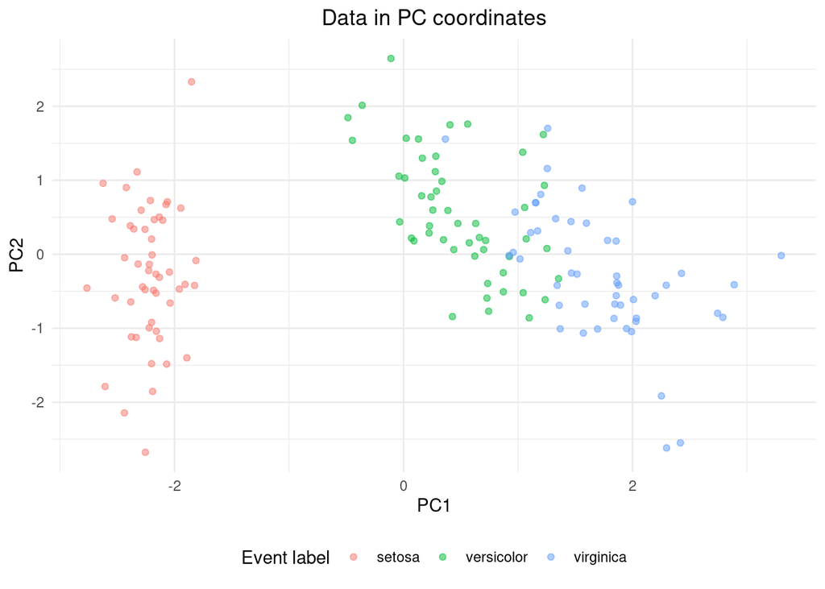

```r
pca_fit |>
  augment(iris) |>
  ggplot(aes(.fittedPC1, .fittedPC2,
             colour = Species)) +
  geom_point(alpha = 0.5) +
  theme_minimal() +
  theme(legend.position = "bottom",
        plot.title = element_text(hjust = 0.5)) +
  labs(x = "PC1",
       y = "PC2",
       title = "Data in PC coordinates",
       colour = "Event label")
```

### Look into the rotation matrix

Secondly, we will **look at the rotation matrix**. We employ the broom package to extract this matrix.

```r
# extract rotation matrix
pca_fit %>%
  tidy(matrix = "rotation")
```

```
# A tibble: 16 × 3
   column          PC   value
   <chr>        <dbl>   <dbl>
 1 Sepal.Length     1  0.521
 2 Sepal.Length     2 -0.377
 3 Sepal.Length     3  0.720
 4 Sepal.Length     4  0.261
 5 Sepal.Width      1 -0.269
 6 Sepal.Width      2 -0.923
 7 Sepal.Width      3 -0.244
 8 Sepal.Width      4 -0.124
 9 Petal.Length     1  0.580
10 Petal.Length     2 -0.0245
11 Petal.Length     3 -0.142
12 Petal.Length     4 -0.801
13 Petal.Width      1  0.565
14 Petal.Width      2 -0.0669
15 Petal.Width      3 -0.634
16 Petal.Width      4  0.524
```

We now visualise the matrix in the context of a plot.

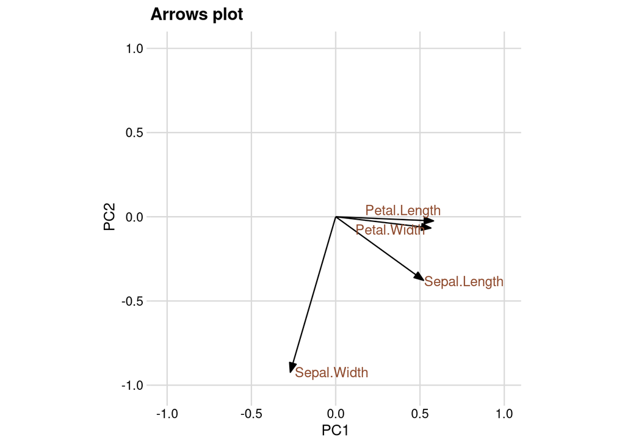

```r
# define arrow style for plotting
arrow_style <- arrow(
  angle = 20, ends = "first", type = "closed", length = grid::unit(8, "pt")
)

# plot rotation matrix
pca_fit %>%
  tidy(matrix = "rotation") %>%
  pivot_wider(names_from = "PC", names_prefix = "PC", values_from = "value") %>%
  ggplot(aes(PC1, PC2)) +
  geom_segment(xend = 0, yend = 0, arrow = arrow_style) +
  geom_text_repel(
    aes(label = column),
    hjust = 1, nudge_x = -0.02,
    color = "#904C2F"
  ) +
  xlim(-1, 1) + ylim(-1, 1) +
  coord_fixed() + # fix aspect ratio to 1:1
  theme_minimal_grid(12) +
  labs(
    title = "Arrows plot"
  )
```

The plot shows us that the first principal component has high values for petal length and width, and sepal length. Sepal width is the variable with the “smallest” effect on it, which also happens to be negative. On the other hand, sepal width has the “strongest” effect on the second principal component, it being a negative one. Sepal length also has a negative effect on this component, whilst the petal measurements have an almost null effect on it.

### Look at the variance explained by each PC

Next, we examine how much variance each principal component explains. We will plot the variance explained by each principal component.

```r
# Extract eigenvalues (variance explained by each PC)
pca_fit |>
  tidy(matrix = 'eigenvalues')
```

```
# A tibble: 4 × 4
     PC std.dev percent cumulative
  <dbl>   <dbl>   <dbl>      <dbl>
1     1   1.71  0.730        0.730
2     2   0.956 0.229        0.958
3     3   0.383 0.0367       0.995
4     4   0.144 0.00518      1
```

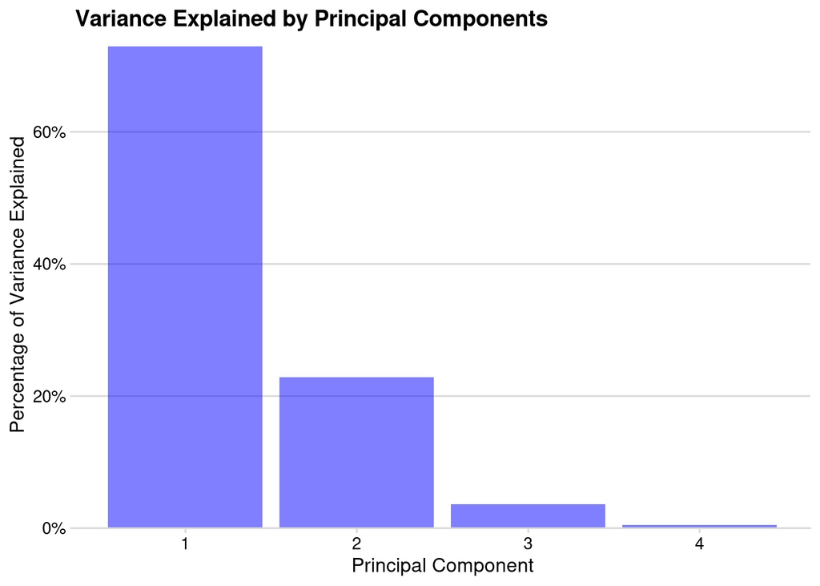

```r
# create a bar plot to show the percentage of variance
pca_fit |>
  tidy(matrix = "eigenvalues") |>
  # Map 'PC' to x-axis and 'percent of variance' to y-axis
  ggplot(aes(PC, percent)) +
  geom_col(fill = "blue", alpha = 0.5) +
  # Format the axis
  scale_x_continuous(breaks = 1:4) +
  scale_y_continuous(
    labels = scales::percent_format(),
    expand = expansion(mult = c(0, 0.01))) +
  # Apply minimal theme with horizontal gridlines
  theme_minimal_hgrid(12) +
  labs(
    title = "Variance Explained by Principal Components",
    x = "Principal Component",
    y = "Percentage of Variance Explained"
)
```

These results represent the summary of principal component analysis (PCA). The first principal component (PC) explains approximately 72.96% of the variance. The second PC explains 22.85% of the variance, while the third and fourth PCs explain progressively smaller amounts, 3.67% and 0.52%, respectively.

The cumulative variance explained by the first two components is around 95.81%, suggesting that a reduced dimensionality using the first two components would retain most of the information from the original data.